# BEST: Behavioural Economics for Social-Ecological Systems with Thresholds

by Juan Carlos Rocha

## BEST: Exploratory analysis

The **BEST** project aims to understand what are the behavioural responses of people who rely on natural resources for their livelihood, and whose resources could potentially present threshold like dynamics, aka. *“regime shifts”*. For this study we designed a game played with fishermen in four communities of the Colombian caribbean. Here I present a short exploration of the game data and survey.

### Where?

The game was performed in four coastal communities of the Colombian Caribbean. Taganga is traditional fishing town that in the last decades has become more of a turistic hub for backpackers. Fishing is still important in the area and is mainly done in the sea, sometimes on the marine territory of Tayrona National Park. Tasajeras is a small fishing community located on the road that communicates Santa Marta and Barranquilla, two major cities. Their location favors fishing both in the sea and inside the Cienaga Grande de Santa Marta, a wetland complex of brakish water, mangroves and a very special ecosystem that depends on the exchange of salt water from the sea and fresh water from the Magdalena river. The inhabitants of Buenavista literally live on the Cienaga. Their houses stand just above water on an area of the Cienaga that is flooded all year round. They are the poorest community we visited and they depend completely on explotation of natural resources for survival. Las Flores, in contrast, is actually a neighbourhood of Barranquilla located in the outskirts of the city. They fish on the Magdalena river’s mouth with very special techniques that use wind and kites to fish on the sea. They also exploit resources in neigbouring wetlands formed by the delta.

We designed the experiment to test for differences on treatment, but also to test for difference on ecological conditions, expecting that communities who rely more strongly on the Cienaga (a closed system that has undergone regime shifts in the past) would behave differently that communities exposed more to oceanic conditions; where variability has perhaps masked/buffered regime shifts.

[figure not shown]

```r
load('~/Documents/Projects/BEST - Beijer/BEST/mapBEST.RData')
ggmap(map) +
  geom_point(aes(x=lon, y=lat, colour='Orange', size=2), data=coords, alpha=0.5,
             show.legend = F) +
  geom_text(aes(x=lon, y=lat), data= coords ,
            label=c('Taganga', 'Tasajeras', 'Buenavista', 'Las Flores'),
            size=4, colour='blue', nudge_y = 0.03) + ggtitle('Study area')
```

## A graphical exploration of the survey

We ran a survey with each of the 256 participants of our fishing game. The 56 questions of the survey are grouped around five topics:

1. the game
2. fishing activities
3. changes in resources and traditional ecological knowledge
4. cooperation and community activities
5. demographic information at household level

For each section I present a series of graphic summaries for questions whose answer was binary or numeric. Later I elaborate on more detailed information for text data. The version of this graphical summary is a lazy version. I’ve written a function that works on any question of the survey but does not modified the x-axis labels for any figure. This allow us to identify preliminary problems with data, e.g. wether it has been errors on digitalizing the raw data. However, unless is explicitely said on the figure label, 0 means *no* and 1 means *yes*.

### 1. The game

Note that Q3 has an error, it should be binary 1/0 and has values of 2. Most people was not expecting the end of the game and wanted to play at least 5 more rounds. That’s good as control for *end of game* effect.

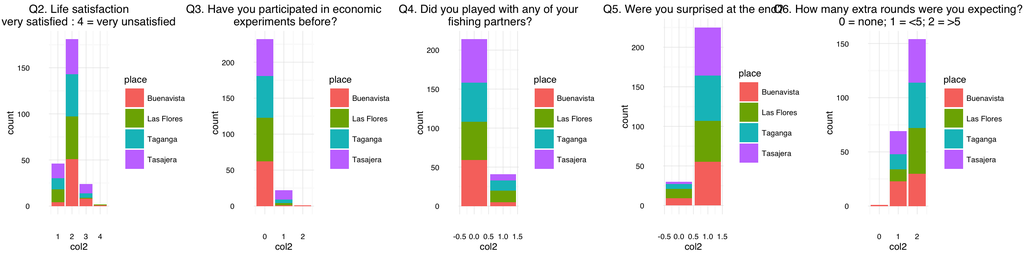

```r
q1 <- question (surv, q1=372, q2=25, q3=2, fun=mean) + ggtitle('Q2. Life satisfaction\n 1= very satisfied : 4 = very unsatisfied')
q2 <- question (surv, q1=372, q2=26, q3 = 2, fun=mean) + ggtitle('Q3. Have you participated in economic\n experiments before?')
q3 <- question (surv, q1=372, q2=27, q3 = 2, fun=mean)  + ggtitle('Q4. Did you played with any of your\n fishing partners?')
q4 <- question (surv, q1=372, q2=28, q3 = 2, fun=mean)  + ggtitle('Q5. Were you surprised at the end?')
q5 <- question (surv, q1=372, q2=29, q3 = 2, fun=mean)  + ggtitle('Q6. How many extra rounds were you expecting?\n 0 = none; 1 = <5; 2 = >5')
grid.arrange(q1,q2,q3,q4,q5, nrow=1, ncol=5)
```

### 2. Fishing activities

Most people started fishing as teenager, however it varies depending of place. For future analysis a density plot might better reveal such differences. We have errors on data input for questions 8 & 10. Most people have been fishermen all then time since they started, and most of them have also been fishing on the same community. For less than half of our sample, people stop fishing at least a month last year (2015)

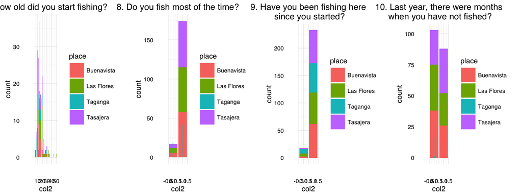

```r
grid.arrange(
  question (surv, q1=372, q2=31, q3 = 2, fun=mean)  + ggtitle('7. How old did you start fishing?'),
  question (surv, q1=372, q2=32, q3 = 2, fun=mean)  + ggtitle('8. Do you fish most of the time?'),
  question (surv, q1=372, q2=33, q3 = 2, fun=mean)  + ggtitle('9. Have you been fishing here\n since you started?'),
  question (surv, q1=372, q2=35, q3 = 2, fun=mean)  + ggtitle('10. Last year, there were months\n when you have not fished?'),
  nrow=1, ncol=4
)
## Warning: position_stack requires non-overlapping x intervals
```

I’d like to get a cleaner version of the fishing calendar (e.g. a heatmap), but for now the figure below summarizes when were people non-fishing last year. Note is a crappy graph, not all plots are on the same scale… but aesthetics apart, one can see that not surprisingly the month when people stop fishing more often is December, probably also due to festivities.

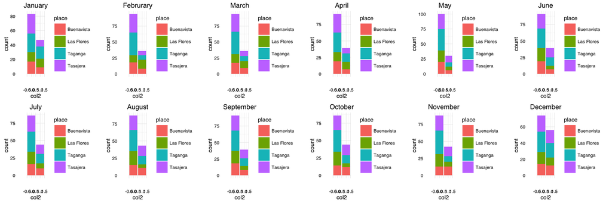

```r
grid.arrange(
  question (surv, q1=372, q2=36, q3 = 2, fun=mean)  + ggtitle('January'),
  question (surv, q1=372, q2=37, q3 = 2, fun=mean)  + ggtitle('Februrary'),
  question (surv, q1=372, q2=38, q3 = 2, fun=mean)  + ggtitle('March'),
  question (surv, q1=372, q2=39, q3 = 2, fun=mean)  + ggtitle('April'),
  question (surv, q1=372, q2=40, q3 = 2, fun=mean)  + ggtitle('May'),
  question (surv, q1=372, q2=41, q3 = 2, fun=mean)  + ggtitle('June'),
  question (surv, q1=372, q2=42, q3 = 2, fun=mean)  + ggtitle('July'),
  question (surv, q1=372, q2=43, q3 = 2, fun=mean)  + ggtitle('August'),
  question (surv, q1=372, q2=44, q3 = 2, fun=mean)  + ggtitle('September'),
  question (surv, q1=372, q2=45, q3 = 2, fun=mean)  + ggtitle('October'),
  question (surv, q1=372, q2=46, q3 = 2, fun=mean)  + ggtitle('November'),
  question (surv, q1=372, q2=47, q3 = 2, fun=mean)  + ggtitle('December'),
  nrow=2, ncol=6
)
```

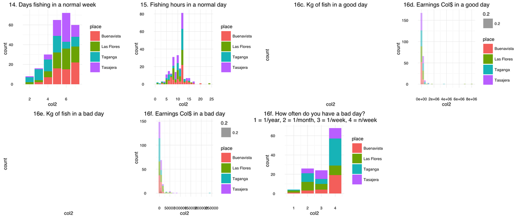

```r
grid.arrange(
  # repeat graph with position = 'dodge' in geom_bar
  question (surv, q1=372, q2=49, q3 = 2, fun=mean)  + ggtitle('14. Days fishing in a normal week'),
  question (surv, q1=372, q2=50, q3 = 2, fun=mean)  + ggtitle('15. Fishing hours in a normal day'),
  #question (surv, q1=372, q2=51, q3 = 2, fun=mean)  + ggtitle('16a. Kg of fish in a normal day'), ## error!!! summary(surv[,51]) reveals there is . and , used for decimals
  #question (surv, q1=372, q2=52, q3 = 2, fun=mean)  + ggtitle('16b. Earnings in Col$ in a normal day'), ## error summary(surv[,52]) # one of the datapoins is 3 million pesos per day!
  question (surv, q1=372, q2=53, q3 = 2, fun=mean)  + ggtitle('16c. Kg of fish in a good day'), # error
  question (surv, q1=372, q2=54, q3 = 2, fun=mean)
    + geom_histogram(aes(alpha=0.2)) + ggtitle('16d. Earnings Col$ in a good day'), # error
  question (surv, q1=372, q2=55, q3 = 2, fun=mean)
    + ggtitle('16e. Kg of fish in a bad day'), # error
  question (surv, q1=372, q2=56, q3 = 2, fun=mean) + geom_histogram(aes(alpha=0.2)) + ggtitle('16f. Earnings Col$ in a bad day'), # error in distribution table(surv[,56])/16
  question (surv, q1=372, q2=57, q3 = 2, fun=mean)
    + ggtitle('16f. How often do you have a bad day?\n 1 = 1/year, 2 = 1/month, 3 = 1/week, 4 = n/week'),
  nrow=2, ncol=4
)
```

Most people fish in company of other fishermen, but almost a fifth of our surveyed fishermen fish alone. Crew size varies across places, very few people fish with crews > 12, and they are from Taganga or Las Flores, the fishing towns where open sea fishing with more industrial styles are possible. In fact, the maximum crew size for Tasajera is 5 and in Buenavista is 3 or 4. Note we have an error on the raw data for Buenavista datapoints. Most people fish with the same crew, but most of the time the decision on when to go fishing is made by other person than the intervieweed. The most typical boat is *bote* which implies a small size vessel without engine or with a small power engine. Only few people (<20) fish on *lanchas* which are bigger boats with more powerful engines, most of them are located in Las Flores where wind and currents are strong due to the Magdalena river delta. Similarly, around 60% of fishermen are not the captain neither own the boat they fish with. They don’t fish on the same places either. Half of the people own their fishing art being ownership most common in Buenavista and less common in Taganga.

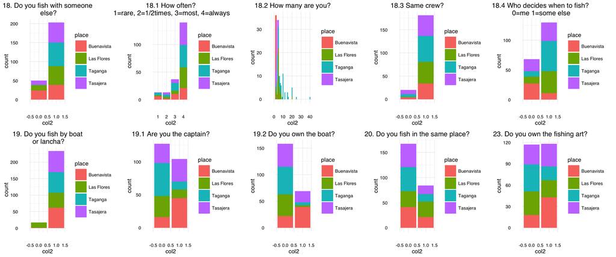

```r
grid.arrange(
  question (surv, q1=372, q2=58, q3 = 2, fun=mean)  + ggtitle('18. Do you fish with someone\n else?'),
  question (surv, q1=372, q2=59, q3 = 2, fun=mean)  + ggtitle('18.1 How often?\n 1=rare, 2=1/2times, 3=most, 4=always'),
  question (surv, q1=372, q2=60, q3 = 2, fun=mean)  + ggtitle('18.2 How many are you?'), # repeat this plot with density table(surv[,60])/16
  question (surv, q1=372, q2=61, q3 = 2, fun=mean)  + ggtitle('18.3 Same crew?'),
  question (surv, q1=372, q2=62, q3 = 2, fun=mean)  + ggtitle('18.4 Who decides when to fish?\n 0=me 1=some else'),
  question (surv, q1=372, q2=64, q3 = 2, fun=mean)  + ggtitle('19. Do you fish by boat\n or lancha?'),
  question (surv, q1=372, q2=65, q3 = 2, fun=mean)  + ggtitle('19.1 Are you the captain?'),
  question (surv, q1=372, q2=66, q3 = 2, fun=mean)  + ggtitle('19.2 Do you own the boat?'),
  question (surv, q1=372, q2=67, q3 = 2, fun=mean)  + ggtitle('20. Do you fish in the same place?'),
  question (surv, q1=372, q2=89, q3 = 2, fun=mean)  + ggtitle('23. Do you own the fishing art?'),
  nrow=2, ncol=5
)
```

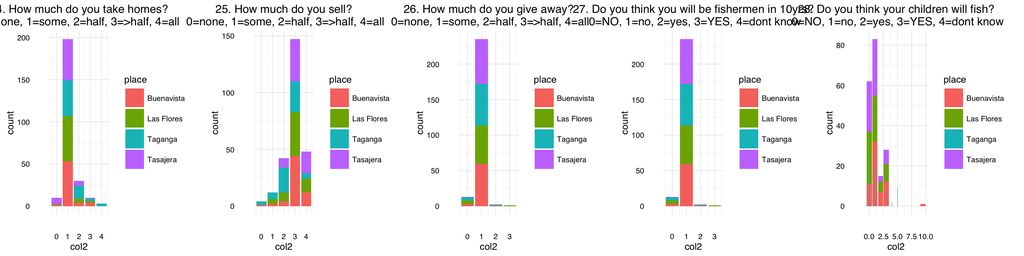

```r
grid.arrange(
  question (surv, q1=372, q2=90, q3 = 2, fun=mean)  + ggtitle('24. How much do you take homes?\n 0=none, 1=some, 2=half, 3=>half, 4=all'),
  question (surv, q1=372, q2=91, q3 = 2, fun=mean)  + ggtitle('25. How much do you sell?\n 0=none, 1=some, 2=half, 3=>half, 4=all'),
  question (surv, q1=372, q2=93, q3 = 2, fun=mean)  + ggtitle('26. How much do you give away?\n 0=none, 1=some, 2=half, 3=>half, 4=all'),
  question (surv, q1=372, q2=93, q3 = 2, fun=mean)  + ggtitle('27. Do you think you will be fishermen in 10yrs?\n 0=NO, 1=no, 2=yes, 3=YES, 4=dont know'),
  question (surv, q1=372, q2=96, q3 = 2, fun=mean)  + ggtitle('28. Do you think your children will fish?\n 0=NO, 1=no, 2=yes, 3=YES, 4=dont know'),
  nrow=1, ncol=5
)
```

### 3. Changes in resources & TEK

When we asked about species dynamics people reported that there has been speces that they don’t fish as much as before. More than 150 respondants report this changes as dramatic. However, this part of the survey is horribly coded. There are errors in data for Tasajera for questions about when the species dissapeared or if is still missing, values should have been numeric but it was not coded that way. Errors lead to no plots produced.

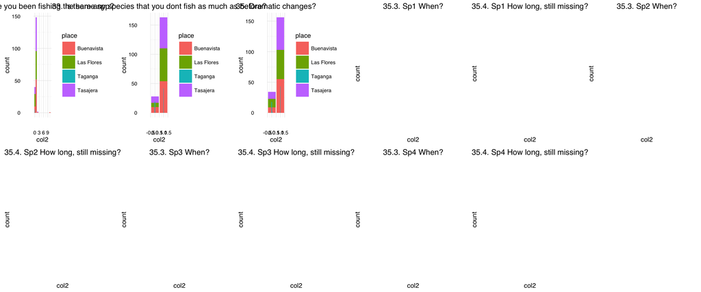

```r
grid.arrange(
  question (surv, q1=372, q2=98, q3 = 2, fun=mean)  + ggtitle('31. Have you been fishing the same spp?'), # should be binary
  question (surv, q1=372, q2=100, q3 = 2, fun=mean)  + ggtitle('33. Is there any species that you dont fish as much as before?'), # error
  question (surv, q1=372, q2=102, q3 = 2, fun=mean)  + ggtitle('35. Dramatic changes?'), # error
  question (surv, q1=372, q2=104, q3 = 2, fun=mean)  + ggtitle('35.3. Sp1 When?'), ### Errors, horribly coded! summary(surv[,104])
  question (surv, q1=372, q2=105, q3 = 2, fun=mean)  + ggtitle('35.4. Sp1 How long, still missing?'),
  question (surv, q1=372, q2=109, q3 = 2, fun=mean)  + ggtitle('35.3. Sp2 When?'),
  question (surv, q1=372, q2=110, q3 = 2, fun=mean)  + ggtitle('35.4. Sp2 How long, still missing?'),
  question (surv, q1=372, q2=114, q3 = 2, fun=mean)  + ggtitle('35.3. Sp3 When?'),
  question (surv, q1=372, q2=115, q3 = 2, fun=mean)  + ggtitle('35.4. Sp3 How long, still missing?'),
  question (surv, q1=372, q2=119, q3 = 2, fun=mean)  + ggtitle('35.3. Sp4 When?'),
  question (surv, q1=372, q2=120, q3 = 2, fun=mean)  + ggtitle('35.4. Sp4 How long, still missing?'),
  nrow=2, ncol=6
)
```

Responses on abrupt events on fishing: In question 35 people were asked if they have experienced an abrupt change (above graph). Questions 36:40 were only asked to people who did experience abrupt changes, so N != 256. People were asked if the abrupt event described on table/question 35 have affected what they fish. Most people answer positively, nevertheless about 40 people say ‘no’ (Q36 error with 10 in Buenavista where it should have been 1/0). Since the occurrance of the event, most people spend more time fishing, less than 20 spends the same or less time respectively. Just above 60 people changed their fishing area while just below 50 didn’t (Q36.3 error non-binary value in Las Flores). Most people expected abrupt changes in the future. Question 39 was a multiple choice answer type, but only to ~50 respondents were read the options out loud. In case of an abrupt event fewer people would continue fishing, most of them won’t increase effort, but they won’t reduce their fishing time neither, less than 40 would consider changing fishing grounds or fishing arts, and most of them wont stop fishing. A lot of questions in this section have coding errors for data in Taganga with contradictory values for the same individual, or with values of 2 when it should be 1/0.

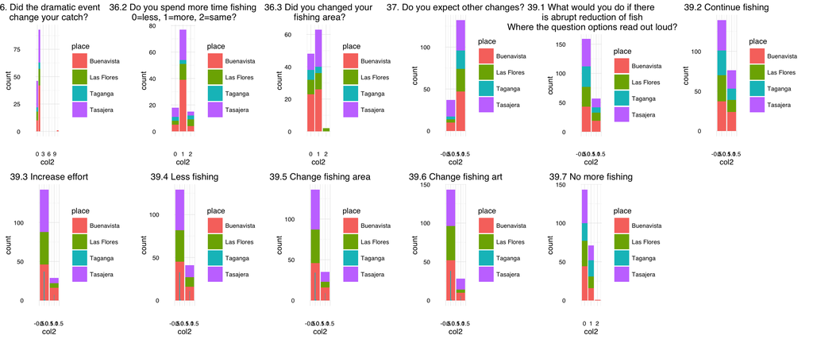

```r
grid.arrange(
  question (surv, q1=372, q2=123, q3 = 2, fun=mean)  + ggtitle('36. Did the dramatic event\n change your catch?'), # error with a 10 in Buenavista
  question (surv, q1=372, q2=125, q3 = 2, fun=mean)  + ggtitle('36.2 Do you spend more time fishing\n 0=less, 1=more, 2=same?'),
  question (surv, q1=372, q2=126, q3 = 2, fun=mean)  + ggtitle('36.3 Did you changed your\n fishing area?'),
  question (surv, q1=372, q2=127, q3 = 2, fun=mean)  + ggtitle('37. Do you expect other changes?'),
  question (surv, q1=372, q2=129, q3 = 2, fun=mean)  + ggtitle('39.1 What would you do if there\n is abrupt reduction of fish\n Where the question options read out loud?'),
  question (surv, q1=372, q2=130, q3 = 2, fun=mean)  + ggtitle('39.2 Continue fishing'),
  question (surv, q1=372, q2=132, q3 = 2, fun=mean)  + ggtitle('39.3 Increase effort'), # error in taganga
  question (surv, q1=372, q2=134, q3 = 2, fun=mean)  + ggtitle('39.4 Less fishing'),# error in taganga
  question (surv, q1=372, q2=136, q3 = 2, fun=mean)  + ggtitle('39.5 Change fishing area'),# error in taganga
  question (surv, q1=372, q2=138, q3 = 2, fun=mean)  + ggtitle('39.6 Change fishing art'), # error taganga
  question (surv, q1=372, q2=140, q3 = 2, fun=mean)  + ggtitle('39.7 No more fishing'), # not binary
  nrow=2, ncol=6
)
```

### 4. Cooperation and community

Most fishermen shared their fishing arts, only ~100 belong to a fishing coop. The community with stronger coop presence is Las Flores (remember the local contact was the coop leader!) while the community with less cooperative participation is Buenavista. People participating in coops usually meet once a month followed by twice a year. Surprisingly, most participants self-report to be treasurers (but there is only one treasurer per coop!?). The graphs about the reasons to belong to a coop doesn’t make much sense. Future versions should compare (bars) for positive answers, here I’m not sure if negative was coded as default or that they did not perceive the benefit. For example, for ‘better prices’ only 20 people report that benefit while ~80 said ‘no’ to that question. Here 0 means that they don’t get the benefit, or that the option was not mentioned? In any case, the most popular positive answers were about recognition as organizaton member and social aspects. Errors: In Q40 is not binary, error in Taganga data; Q42.3 has errors due to coding, for questions where time was asked interviewers were not consistent on the way they wrote down answers. Some times they used years, months, numbers, text and for now we cannot extract the info automatically.

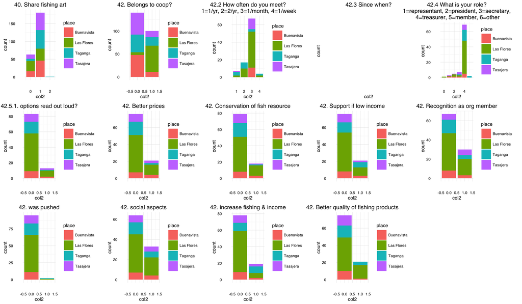

```r
grid.arrange(
  question (surv, q1=372, q2=143, q3 = 2, fun=mean)  + ggtitle('40. Share fishing art'), # error not binary
  question (surv, q1=372, q2=145, q3 = 2, fun=mean)  + ggtitle('42. Belongs to coop?'),
  question (surv, q1=372, q2=147, q3 = 2, fun=mean)  + ggtitle('42.2 How often do you meet?\n 1=1/yr, 2=2/yr, 3=1/month, 4=1/week'), # not binary
  question (surv, q1=372, q2=148, q3 = 2, fun=mean)  + ggtitle('42.3 Since when?'), # error due to coding summary(surv[,148])
  question (surv, q1=372, q2=149, q3 = 2, fun=mean)  + ggtitle('42.4 What is your role?\n 1=representant, 2=president, 3=secretary, \n 4=treasurer, 5=member, 6=other'),
  question (surv, q1=372, q2=152, q3 = 2, fun=mean)  + ggtitle('42.5.1. options read out loud?'),
  question (surv, q1=372, q2=153, q3 = 2, fun=mean)  + ggtitle('42. Better prices'),
  question (surv, q1=372, q2=154, q3 = 2, fun=mean)  + ggtitle('42. Conservation of fish resource'),
  question (surv, q1=372, q2=155, q3 = 2, fun=mean)  + ggtitle('42. Support if low income'),
  question (surv, q1=372, q2=156, q3 = 2, fun=mean)  + ggtitle('42. Recognition as org member'),
  question (surv, q1=372, q2=157, q3 = 2, fun=mean)  + ggtitle('42. was pushed'),
  question (surv, q1=372, q2=158, q3 = 2, fun=mean)  + ggtitle('42. social aspects'),
  question (surv, q1=372, q2=159, q3 = 2, fun=mean)  + ggtitle('42. increase fishing & income'),
  question (surv, q1=372, q2=160, q3 = 2, fun=mean)  + ggtitle('42. Better quality of fishing products'),
  nrow=3, ncol=5
)
```

### 5. Demographics

Almost all our game participants were male fishermen, most of them married or in co-habitation with partner. The average age for the full sample is 42.3913043 and the median is 42. Our sample is younger in Taganga and older in Las Flores. Most people finished elementary school, over 25 respondents didn’t have any formal education, and less than 20 had university degrees almost all of them from Taganga (There is an error with 0 - datapoint in Tasajeras). Most respondants were born on the community but ~70 of them came from somewhere else (error data point with 10). About 40 people have been moving around while <200 have always live in the same community.

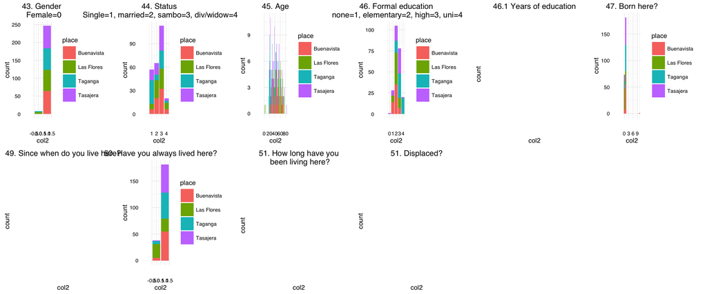

```r
grid.arrange(
  question (surv, q1=372, q2=161, q3 = 2, fun=mean)  + ggtitle('43. Gender \n Female=0'),
  question (surv, q1=372, q2=162, q3 = 2, fun=mean)  + ggtitle('44. Status\n Single=1, married=2, sambo=3, div/widow=4'),
  question (surv, q1=372, q2=163, q3 = 2, fun=mean)  + ggtitle('45. Age'),
  question (surv, q1=372, q2=164, q3 = 2, fun=mean)  + ggtitle('46. Formal education\n none=1, elementary=2, high=3, uni=4'),
  question (surv, q1=372, q2=165, q3 = 2, fun=mean)  + ggtitle('46.1 Years of education'), # error on coding
  question (surv, q1=372, q2=166, q3 = 2, fun=mean)  + ggtitle('47. Born here?'), # error non binary
  question (surv, q1=372, q2=168, q3 = 2, fun=mean)  + ggtitle('49. Since when do you live here?'), # error coding
  question (surv, q1=372, q2=169, q3 = 2, fun=mean)  + ggtitle('50. Have you always lived here?'),
  question (surv, q1=372, q2=170, q3 = 2, fun=mean)  + ggtitle('51. How long have you\n been living here?'), #error coding
  question (surv, q1=372, q2=171, q3 = 2, fun=mean)  + ggtitle('51. Displaced?'), # error coding summary(surv[,171])

  nrow=2, ncol=6
)
```

When asking if they have suffered forced displacement the answers were coding on diverse formats and we cannot plot the info at the moment. However, few respondents (n=5) report forced displacement from 6 months up to 7 years. Question 52 was designed to assess sense of place. Each participant was asked to agree or disagree on a scale from 1 to 4 (1=strongly agree, 2=agree, 3=disagree, 4 strongly disagree) with statements that were read outloud for them. The figure below summarize their answers per location but I’m not quite sure how to interpret them.

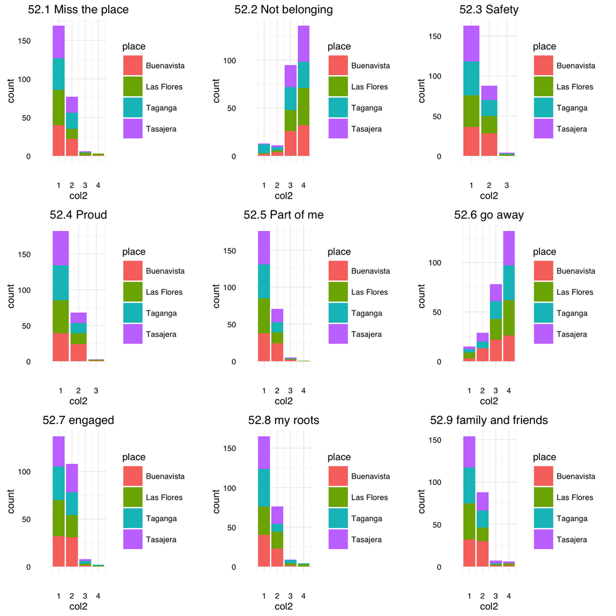

```r
grid.arrange(

  question (surv, q1=372, q2=172, q3 = 2, fun=mean)  + ggtitle('52.1 Miss the place'),
  question (surv, q1=372, q2=173, q3 = 2, fun=mean)  + ggtitle('52.2 Not belonging'),
  question (surv, q1=372, q2=174, q3 = 2, fun=mean)  + ggtitle('52.3 Safety'),
  question (surv, q1=372, q2=175, q3 = 2, fun=mean)  + ggtitle('52.4 Proud'),
  question (surv, q1=372, q2=176, q3 = 2, fun=mean)  + ggtitle('52.5 Part of me'),
  question (surv, q1=372, q2=177, q3 = 2, fun=mean)  + ggtitle('52.6 go away'),
  question (surv, q1=372, q2=178, q3 = 2, fun=mean)  + ggtitle('52.7 engaged'),
  question (surv, q1=372, q2=179, q3 = 2, fun=mean)  + ggtitle('52.8 my roots'),
  question (surv, q1=372, q2=180, q3 = 2, fun=mean)  + ggtitle('52.9 family and friends'),
  nrow=3, ncol=3
)
```